# Part iA: Predictors (Word count features)

INFSCI 2595 Final

Ben Stein

4/27/2022

# About this document

In this document, I perform exploratory data analysis on the word-count-related inputs.

# Setup

## Libraries and tools

```r
library(tidyverse)
source("./tools.R")
```

## Data

```r
df <- load_project_data() %>%
  select(response_log, outcome_numeric, starts_with("xw"))

df %>% glimpse
```

```
## Rows: 677
## Columns: 5
## $ response_log    <dbl> 0.9624073, 0.1694321, 0.7959862, 1.0030975, 0.3942847,~
## $ outcome_numeric <dbl> 0, 0, 1, 0, 0, 0, 0, 0, 0, 0, 0, 0, 0, 0, 0, 0, 0, 1, ~
## $ xw_01           <dbl> 23.00000, 17.00000, 52.50000, 64.52564, 54.75758, 58.3~
## $ xw_02           <dbl> 23, 17, 48, 0, 12, 15, 0, 0, 0, 7, 14, 0, 0, 0, 8, 8, ~
## $ xw_03           <dbl> 23, 17, 57, 106, 105, 101, 107, 109, 109, 104, 109, 99~
```

# Distributions

Let’s look at the distributions of the variables first.

```r
df %>%
  select(-outcome_numeric, -response_log) %>%
  summary
```

```
##      xw_01            xw_02            xw_03
##  Min.   :  9.00   Min.   :  0.00   Min.   :  9.00
##  1st Qu.: 44.36   1st Qu.:  9.00   1st Qu.: 58.00
##  Median : 57.41   Median : 24.00   Median : 93.00
##  Mean   : 57.02   Mean   : 31.87   Mean   : 79.07
##  3rd Qu.: 67.50   3rd Qu.: 49.00   3rd Qu.:101.00
##  Max.   :108.00   Max.   :108.00   Max.   :113.00
```

Like the sentimentR features, these have more similar scale to one another.

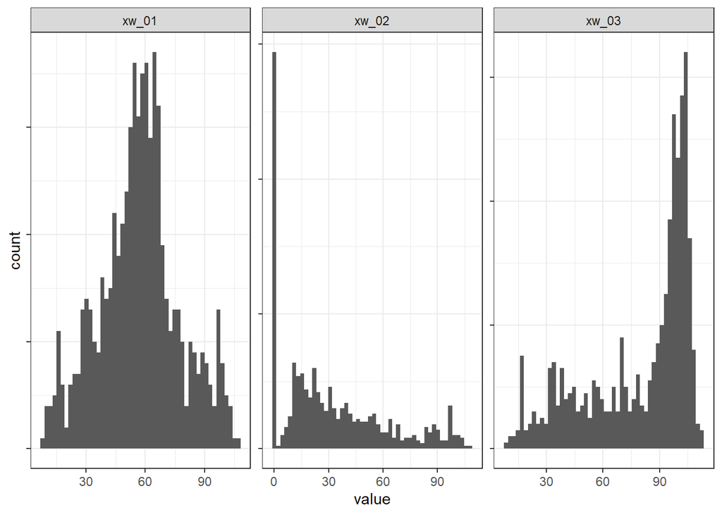

```r
visualize_distributions(df, "xw")
```

In this group, `xw_01` is normally distributed, while the others are more odd. `xw_03` is left-tailed.

## Distinct values

As I worked with each group of continuous predictors, I noticed that some seem to have more unique values than others. Let’s quantify that:

```r
df %>%
  select(-outcome_numeric, -response_log) %>%
  pivot_longer(cols = everything()) %>%
  group_by(name) %>%
  unique %>%
  count
```

```
## # A tibble: 3 x 2
## # Groups:   name [3]
##   name      n
##   <chr> <int>
## 1 xw_01   396
## 2 xw_02   102
## 3 xw_03   103
```

`xw_01` has more distinct values than the other two by a noticeable amount. Combined with the fact that this variable has the most Gaussian distribution, that suggests that the true distribution may be Gaussian.

# Correlation within the group

Let’s see if any of these inputs are correlated with one another or with the response variable.

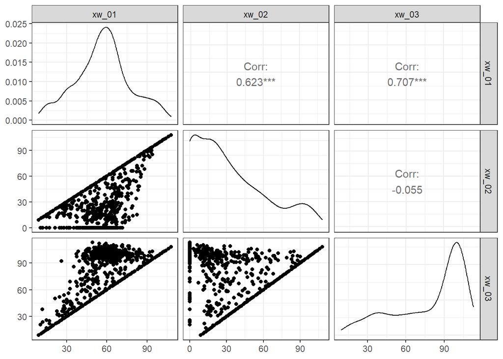

```r
visualize_correlations(df, "xw")
```

`xw_01` is highly correlated with the other two inputs, suggesting we should only use one of these at a time.

# Relationship to target variables

## The continuous `response` variable

Note that I log-transformed response since that’s what I’ll be predicting anyway.

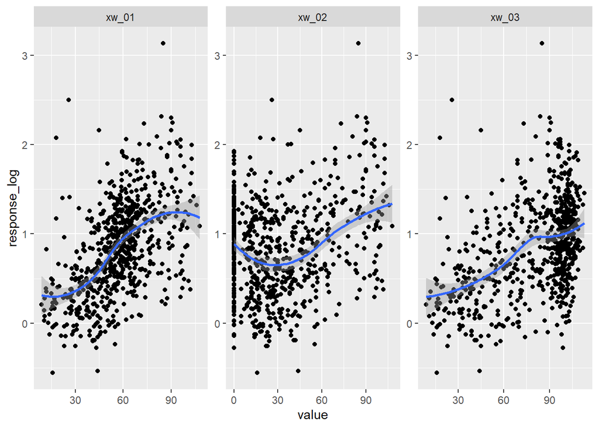

```r
df %>%
  pivot_longer(cols = starts_with("xw")) %>%
  ggplot(mapping = aes(x = value, y = response_log)) +
  geom_point() +
  geom_smooth(formula = y ~ x, method = "loess") +
  facet_wrap(~ name, scales = "free")
```

These relationships look more linear than some of the other predictors, but a little curvy. A low order polynomial might be worth a try.

## The `outcome` classification target

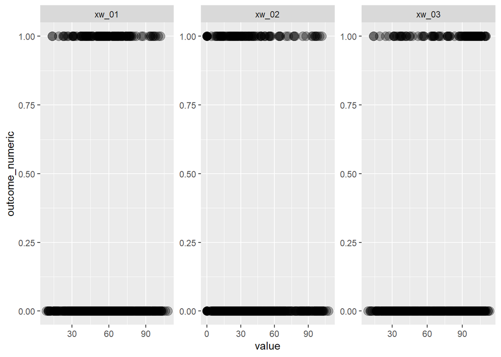

```r
df %>%
  select(-response_log) %>%
  pivot_longer(cols = starts_with("xw")) %>%
  ggplot(mapping = aes(x = value, y = outcome_numeric)) +
  geom_point(size = 4, alpha = .33) +
  facet_wrap(~ name, scales = "free")
```

Like the sentimentR group, there’s not a clear trend between values of these variables and the `outcome` variable.